# Basal Ganglia Spiking Tutorial Solutions

Author: Matthew J. Crossley

Last update: 24 April, 2026

## Solutions overview

This document includes only the completed code and short answers. Use it alongside the main tutorial rather than as a standalone handout.

## 1. Setup code

```python
import numpy as np
import matplotlib.pyplot as plt

dt = 0.1
T = 3000
t = np.arange(0, T, dt)
n_steps = t.shape[0]

np.random.seed(0)

I_amp = 300
I_in = np.zeros(n_steps)
I_in[n_steps // 3:2 * n_steps // 3] = I_amp

ctx = 0
d1 = 1
d2 = 2
gpi = 3
gpe = 4
th = 5
stn = 6
pm = 7

labels = {
    ctx: "Sensory Cortex",
    d1: "D1 Striatum",
    d2: "D2 Striatum",
    gpi: "GPi",
    gpe: "GPe",
    th: "Thalamus",
    stn: "STN",
    pm: "Motor Cortex",
}

iz_params = np.array([
    [100, -60, -40, 35, 0.03, -2, -50, 100, 0.7],
    [50, -80, -25, 40, 0.01, -20, -55, 150, 1.0],
    [50, -80, -25, 40, 0.01, -20, -55, 150, 1.0],
    [100, -60, -40, 35, 0.03, -2, -50, 100, 0.7],
    [100, -60, -40, 35, 0.03, -2, -50, 100, 0.7],
    [100, -60, -40, 35, 0.03, -2, -50, 100, 0.7],
    [100, -60, -40, 35, 0.03, -2, -50, 100, 0.7],
    [100, -60, -40, 35, 0.03, -2, -50, 100, 0.7],
])

n_cells = iz_params.shape[0]

E_base = np.array([0, 0, 0, 300, 260, 0, 0, 0], dtype=float)

psp_amp = 1000
psp_decay = 100
```

## 2. Helper code

```python
def simulate_network(W, E):
    v = np.zeros((n_cells, n_steps))
    u = np.zeros((n_cells, n_steps))
    g = np.zeros((n_cells, n_steps))
    spike = np.zeros((n_cells, n_steps))

    v[:, 0] = iz_params[:, 1] + np.random.rand(n_cells) * 5
    u[:, 0] = iz_params[:, 5] * (v[:, 0] - iz_params[:, 1])

    for i in range(1, n_steps):
        dt = t[i] - t[i - 1]

        I_net = W.T @ g[:, i - 1]
        I_net[ctx] += I_in[i - 1]
        I_net[th] += I_in[i - 1]
        I_net += E

        for j in range(n_cells):
            C, vr, vt, vpeak, a, b, c, d, k = iz_params[j]

            dvdt = (k * (v[j, i - 1] - vr) * (v[j, i - 1] - vt) - u[j, i - 1] + I_net[j]) / C
            dudt = a * (b * (v[j, i - 1] - vr) - u[j, i - 1])
            dgdt = (-g[j, i - 1] + psp_amp * spike[j, i - 1]) / psp_decay

            v[j, i] = v[j, i - 1] + dvdt * dt
            u[j, i] = u[j, i - 1] + dudt * dt
            g[j, i] = g[j, i - 1] + dgdt * dt

            if v[j, i] >= vpeak:
                v[j, i - 1] = vpeak
                v[j, i] = c
                u[j, i] += d
                spike[j, i] = 1

    return v, g, spike


def plot_pathway_columns(
    v,
    g,
    columns,
    title
):
    fig, ax = plt.subplots(
        5,
        len(columns),
        squeeze=False,
        figsize=(10.5, 7.8),
        sharex=True
    )
    fig.suptitle(title)

    for col, (column_title, cell_list) in enumerate(columns):
        for row, cell_idx in enumerate(cell_list):
            ax1 = ax[row, col]
            if cell_idx is None:
                ax1.axis("off")
                continue
            ax2 = ax1.twinx()
            ax1.plot(t, v[cell_idx, :], color="C0", alpha=0.25)
            ax2.plot(
                t,
                g[cell_idx, :],
                color="C1",
                alpha=1.0,
                linewidth=2.0
            )
            if row == 0:
                ax1.set_title(column_title)
            ax1.set_ylabel(labels[cell_idx], fontsize=8)

    plt.tight_layout()
    plt.show()
```

## 3. Direct pathway

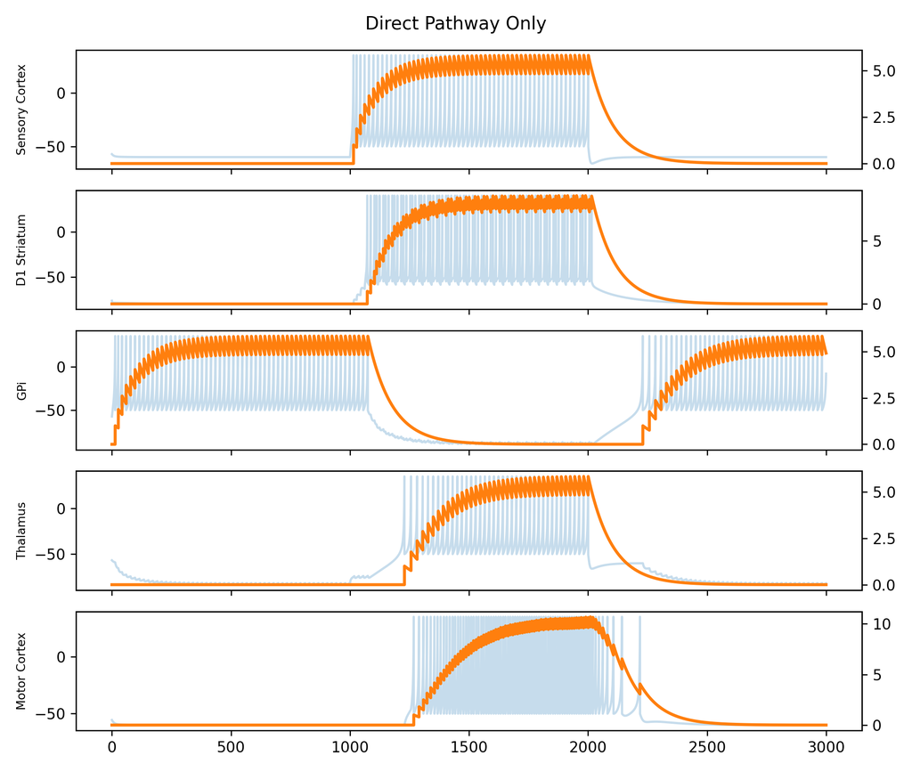

```python
W = np.zeros((n_cells, n_cells))
W[ctx, d1] = 250
W[d1, gpi] = -150
W[gpi, th] = -120
W[th, pm] = 120

v = np.zeros((n_cells, n_steps))
u = np.zeros((n_cells, n_steps))
g = np.zeros((n_cells, n_steps))
spike = np.zeros((n_cells, n_steps))

v[:, 0] = iz_params[:, 1] + np.random.rand(n_cells) * 5
u[:, 0] = iz_params[:, 5] * (v[:, 0] - iz_params[:, 1])

for i in range(1, n_steps):
    dt = t[i] - t[i - 1]

    I_net = W.T @ g[:, i - 1]
    I_net[ctx] += I_in[i - 1]
    I_net[th] += I_in[i - 1]
    I_net += E_base

    for j in range(n_cells):
        C, vr, vt, vpeak, a, b, c, d, k = iz_params[j]

        dvdt = (k * (v[j, i - 1] - vr) * (v[j, i - 1] - vt) - u[j, i - 1] + I_net[j]) / C
        dudt = a * (b * (v[j, i - 1] - vr) - u[j, i - 1])
        dgdt = (-g[j, i - 1] + psp_amp * spike[j, i - 1]) / psp_decay

        v[j, i] = v[j, i - 1] + dvdt * dt
        u[j, i] = u[j, i - 1] + dudt * dt
        g[j, i] = g[j, i - 1] + dgdt * dt

        if v[j, i] >= vpeak:
            v[j, i - 1] = vpeak
            v[j, i] = c
            u[j, i] += d
            spike[j, i] = 1

plot_cells = [ctx, d1, gpi, th, pm]
fig, ax = plt.subplots(len(plot_cells), 1, squeeze=False, figsize=(8.5, 7.2), sharex=True)
fig.suptitle("Direct Pathway Only")

for row, cell_idx in enumerate(plot_cells):
    ax1 = ax[row, 0]
    ax2 = ax1.twinx()
    ax1.plot(t, v[cell_idx, :], color="C0", alpha=0.25)
    ax2.plot(t, g[cell_idx, :], color="C1", alpha=1.0, linewidth=2.0)
    ax1.set_ylabel(labels[cell_idx], fontsize=8)

plt.tight_layout()
plt.show()
```

- `ctx -> d1` is excitatory, `d1 -> gpi` is inhibitory, `gpi -> th` is inhibitory, and `th -> pm` is excitatory.
- Disinhibition happens because D1 suppresses GPi, which releases thalamus from inhibition.
- If `W[d1, gpi]` becomes less negative, the direct pathway becomes weaker and thalamocortical facilitation is reduced.
- The thalamic support term stands in for excitatory influences such as cortex, cerebellum, and brainstem input.

## 4. Indirect pathway

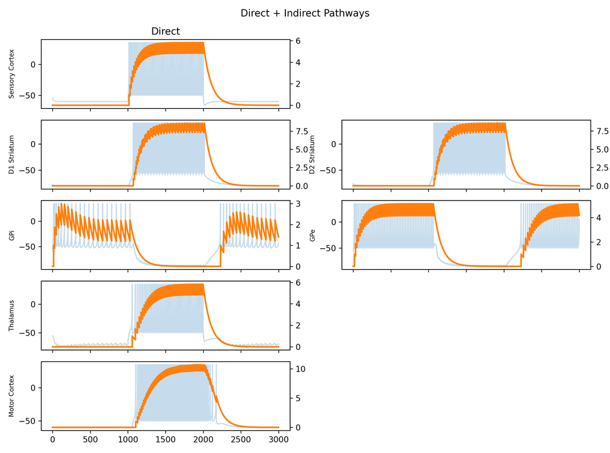

```python
W = np.zeros((n_cells, n_cells))
W[ctx, d1] = 250
W[d1, gpi] = -150
W[ctx, d2] = 250
W[d2, gpe] = -120
W[gpe, gpi] = -40
W[gpi, th] = -120
W[th, pm] = 120

v, g, spike = simulate_network(W, E_base)
columns = [
    ("Direct", [ctx, d1, gpi, th, pm]),
    ("Indirect", [None, d2, gpe, None, None]),
]
plot_pathway_columns(v, g, columns, "Direct + Indirect Pathways")
```

- The indirect pathway is `ctx -> d2`, `d2 -> gpe`, `gpe -> gpi`.
- D2 inhibits GPe, GPe inhibits GPi, so suppressing GPe removes inhibition from GPi and lets GPi inhibit thalamus more strongly.
- Making `W[d2, gpe]` more negative strengthens suppression of thalamocortical output.
- The compressed `D2 -> GPe -> GPi` version is acceptable here because it captures the same net sign on GPi and thalamus.

## 5. Hyperdirect pathway

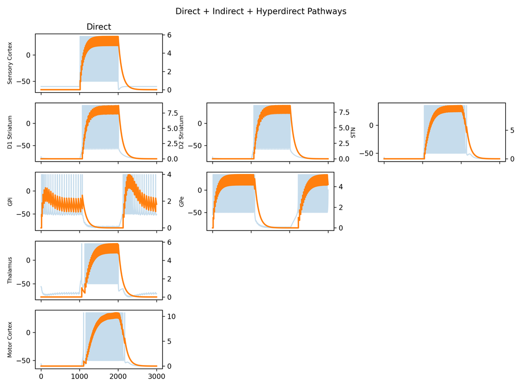

```python
W = np.zeros((n_cells, n_cells))
W[ctx, d1] = 250
W[d1, gpi] = -150
W[ctx, d2] = 250
W[d2, gpe] = -120
W[gpe, gpi] = -40
W[ctx, stn] = 100
W[stn, gpi] = 50
W[gpi, th] = -120
W[th, pm] = 120

v, g, spike = simulate_network(W, E_base)
columns = [
    ("Direct", [ctx, d1, gpi, th, pm]),
    ("Indirect", [None, d2, gpe, None, None]),
    ("Hyperdirect", [None, stn, None, None, None]),
]
plot_pathway_columns(v, g, columns, "Direct + Indirect + Hyperdirect Pathways")
```

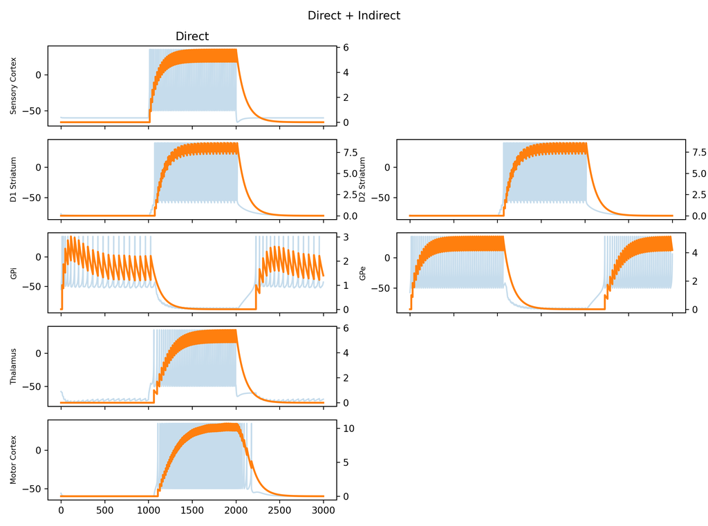

```python
W_direct_indirect = np.zeros((n_cells, n_cells))
W_direct_indirect[ctx, d1] = 250
W_direct_indirect[d1, gpi] = -150
W_direct_indirect[ctx, d2] = 250
W_direct_indirect[d2, gpe] = -120
W_direct_indirect[gpe, gpi] = -40
W_direct_indirect[gpi, th] = -120
W_direct_indirect[th, pm] = 120

W_direct_hyperdirect = np.zeros((n_cells, n_cells))
W_direct_hyperdirect[ctx, d1] = 250
W_direct_hyperdirect[d1, gpi] = -150
W_direct_hyperdirect[ctx, stn] = 100
W_direct_hyperdirect[stn, gpi] = 50
W_direct_hyperdirect[gpi, th] = -120
W_direct_hyperdirect[th, pm] = 120

v_ind, g_ind, _ = simulate_network(W_direct_indirect, E_base)
columns = [
    ("Direct", [ctx, d1, gpi, th, pm]),
    ("Indirect", [None, d2, gpe, None, None]),
]
plot_pathway_columns(v_ind, g_ind, columns, "Direct + Indirect")
```

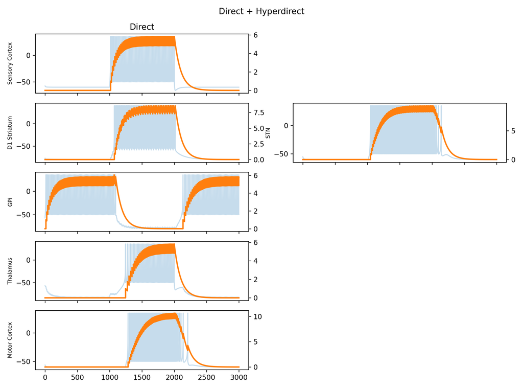

```python
v_hyp, g_hyp, _ = simulate_network(W_direct_hyperdirect, E_base)
columns = [
    ("Direct", [ctx, d1, gpi, th, pm]),
    ("Hyperdirect", [None, stn, None, None, None]),
]
plot_pathway_columns(v_hyp, g_hyp, columns, "Direct + Hyperdirect")
```

- Hyperdirect adds `ctx -> stn` and `stn -> gpi`.
- Direct and hyperdirect start from the same sensory input but have opposite net effects on GPi.
- Hyperdirect is usually described as faster because it reaches GPi through fewer intermediate steps than the indirect pathway.
- Reducing `W[ctx, stn]` weakens the GPi-driving effect of the hyperdirect pathway.

## 6. Dopamine modulation

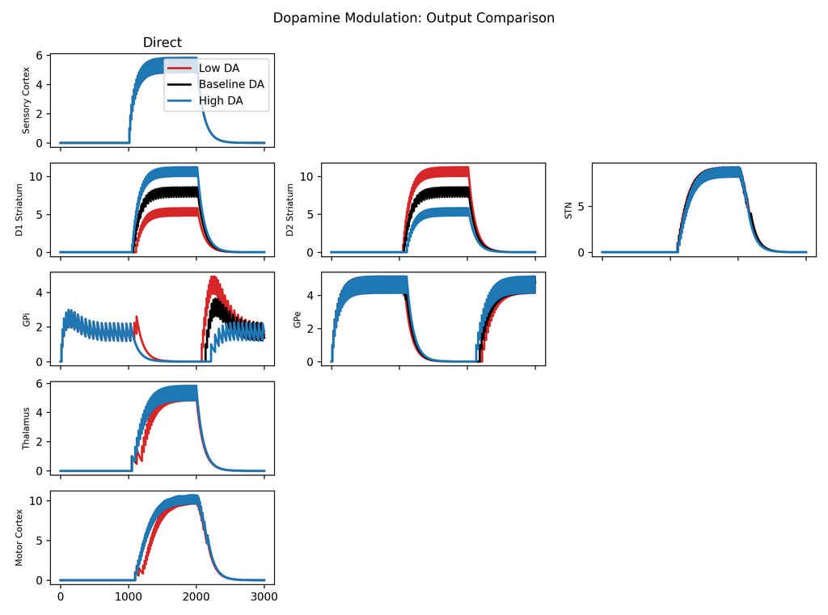

```python
W_base = np.zeros((n_cells, n_cells))
W_base[ctx, d1] = 250
W_base[d1, gpi] = -150
W_base[ctx, d2] = 250
W_base[d2, gpe] = -120
W_base[gpe, gpi] = -40
W_base[ctx, stn] = 100
W_base[stn, gpi] = 50
W_base[stn, gpe] = 20
W_base[gpe, stn] = -50
W_base[gpi, th] = -120
W_base[th, pm] = 120

da_conditions = [
    ("Low DA", -0.5),
    ("Baseline DA", 0.0),
    ("High DA", 0.5),
]
k_da = 0.6

da_results = []
for da_label, da_level in da_conditions:
    W = W_base.copy()
    d1_scale = max(0.0, 1 + k_da * da_level)
    d2_scale = max(0.0, 1 - k_da * da_level)
    W[ctx, d1] = W_base[ctx, d1] * d1_scale
    W[ctx, d2] = W_base[ctx, d2] * d2_scale
    v, g, spike = simulate_network(W, E_base)
    da_results.append((da_label, v, g))

columns = [
    ("Direct", [ctx, d1, gpi, th, pm]),
    ("Indirect", [None, d2, gpe, None, None]),
    ("Hyperdirect", [None, stn, None, None, None]),
]
fig, ax = plt.subplots(5, len(columns), squeeze=False, figsize=(10.5, 7.8), sharex=True)
fig.suptitle("Dopamine Modulation: Output Comparison")
colors = {
    "Low DA": "tab:red",
    "Baseline DA": "black",
    "High DA": "tab:blue",
}

for col, (column_title, cell_list) in enumerate(columns):
    for row, cell_idx in enumerate(cell_list):
        ax1 = ax[row, col]
        if cell_idx is None:
            _ = ax1.axis("off")
            continue
        for da_label, v, g in da_results:
            _ = ax1.plot(t, g[cell_idx, :], color=colors[da_label], linewidth=2.0, label=da_label)
        if row == 0:
            _ = ax1.set_title(column_title)
        _ = ax1.set_ylabel(labels[cell_idx], fontsize=8)
        if row == 0 and col == 0:
            _ = ax1.legend(loc="upper right")

_ = plt.tight_layout()
plt.show()
```

- This model implements dopamine as a pathway-balance change, not a uniform increase in activity.
- Higher dopamine strengthens `ctx -> d1` and weakens `ctx -> d2`, so GPi tends to be reduced and thalamocortical output tends to be facilitated.
- Reducing `k_da` makes the low- versus high-dopamine differences smaller.